# Chapter 5 In-Class R Demo: ARMA Models

## Demo Goal

You will see how AR persistence and the short memory of the MA part combine in an ARMA model.

Reference anchor: ARMA structure, ACF/PACF tailing, residual checking.

```r
set.seed(311)
par(mfrow = c(1, 1))
```

## 1. Compare AR, MA, and ARMA

As in the notes, the MA part is written with minus signs, $\theta(B) = 1 - \theta B$, and R is given `ma = -theta`.

Before running the chunk, predict which ACF or PACF should cut off, using the identification table from Chapter 4.

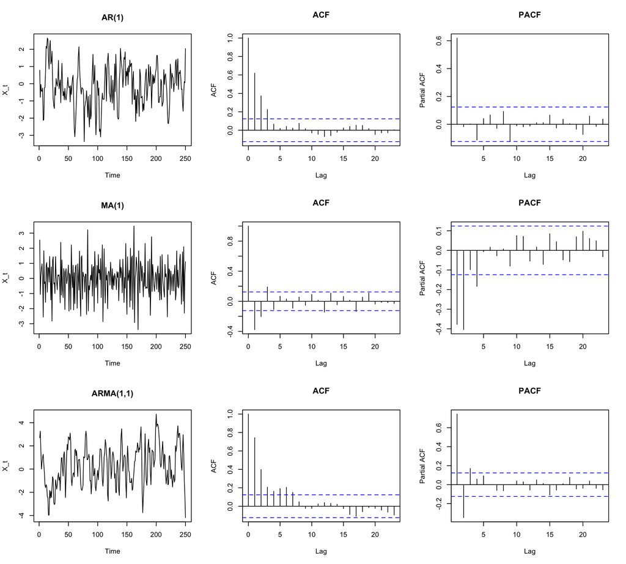

```r
n <- 250
# X_t = 0.7 X_{t-1} + eps_t
x_ar <- arima.sim(model = list(ar = 0.7), n = n)
# X_t = eps_t - 0.7 eps_{t-1}        (theta = 0.7)
x_ma <- arima.sim(model = list(ma = -0.7), n = n)
# X_t = 0.7 X_{t-1} + eps_t + 0.5 eps_{t-1}   (phi = 0.7, theta = -0.5)
x_arma <- arima.sim(model = list(ar = 0.7, ma = 0.5), n = n)

par(mfrow = c(3, 3))
plot.ts(x_ar, main = "AR(1)", ylab = "X_t")
acf(x_ar, main = "ACF")
pacf(x_ar, main = "PACF")
plot.ts(x_ma, main = "MA(1)", ylab = "X_t")
acf(x_ma, main = "ACF")
pacf(x_ma, main = "PACF")
plot.ts(x_arma, main = "ARMA(1,1)", ylab = "X_t")
acf(x_arma, main = "ACF")
pacf(x_arma, main = "PACF")
```

```r
par(mfrow = c(1, 1))
```

Questions:

- Which model has gradual memory?
- Which model has the shortest memory?
- Why can ARMA be harder to identify?

What the commands do:

- `arima.sim()` generates a stationary series from the coefficients in `model`.
- `ma = 0.5` means that R adds $0.5\epsilon_{t-1}$; in the notes this is $\theta = -0.5$.
- `par(mfrow = c(3, 3))` puts one model on each row: series, ACF, then PACF.
- Resetting `par()` to `c(1, 1)` makes the next plot use the whole figure.

### Theory Versus Sample

The sample ACF is an estimate. Compare it with the theoretical ACF of the same ARMA(1,1), keeping the MA sign convention unchanged.

```r
data.frame(
  lag = 0:6,
  theory = round(ARMAacf(ar = 0.7, ma = 0.5, lag.max = 6), 3),
  sample = round(as.numeric(acf(x_arma, lag.max = 6, plot = FALSE)$acf), 3)
)
```

```
##   lag theory sample
## 0   0  1.000  1.000
## 1   1  0.831  0.744
## 2   2  0.582  0.398
## 3   3  0.407  0.207
## 4   4  0.285  0.163
## 5   5  0.199  0.191
## 6   6  0.140  0.205
```

What the commands do:

- `ARMAacf()` calculates population correlations from the model coefficients.
- `plot = FALSE` returns the sample correlations without drawing another plot.
- `$acf` extracts those values; the ACF includes lag 0.

Try it yourself:

- Change `n` to `1000` and rerun from the comparison chunk. Do the sample correlations generally move closer to the theoretical ones?
- Set `ma = 0` for `x_arma`. Which simpler model remains?

## 2. Fit Competing Models

The three candidates use the same observations. We compare their fit while penalising the number of estimated parameters: smaller AIC or BIC is preferred.

```r
fit_ar <- arima(x_arma, order = c(1, 0, 0))
fit_ma <- arima(x_arma, order = c(0, 0, 1))
fit_arma <- arima(x_arma, order = c(1, 0, 1))

AIC(fit_ar, fit_ma, fit_arma)
```

```
##          df      AIC
## fit_ar    3 773.4811
## fit_ma    3 793.1549
## fit_arma  4 730.4192
```

```r
BIC(fit_ar, fit_ma, fit_arma)
```

```
##          df      BIC
## fit_ar    3 784.0455
## fit_ma    3 803.7193
## fit_arma  4 744.5051
```

```r
fit_arma    # R's ma1 is -theta_hat
```

```
##
## Call:
## arima(x = x_arma, order = c(1, 0, 1))
##
## Coefficients:
##          ar1     ma1  intercept
##       0.5890  0.5218     0.2656
## s.e.  0.0606  0.0609     0.2381
##
## sigma^2 estimated as 1.048:  log likelihood = -361.21,  aic = 730.42
```

What the commands do:

- `order = c(p, d, q)` sets the AR order, number of differences and MA order.
- `arima()` estimates the coefficients rather than using the simulation values.
- For this stationary model, R’s `intercept` is the series mean, not the constant in the uncentred ARMA equation.
- `AIC()` and `BIC()` compare the candidates; neither guarantees recovery of the true model from a finite sample.

Questions:

- Does the information criterion identify the data-generating model?
- Compare `ar1` with $\phi = 0.7$ and `-ma1` (that is $\hat\theta$) with $\theta = -0.5$. Are the true values inside estimate $\pm 1.96$ s.e.?
- Change the simulation to `ma = -0.5` ($\theta = 0.5$), so that the factors $1 - 0.7B$ and $1 - 0.5B$ are close, and refit. What happens to the standard errors and to the AIC ranking? (Part 4 explains why.)
- What happens if the sample size is small?

## 3. Residual Diagnostics

If the model has described the serial correlation, little should remain in the residual ACF. Check the plot as well as the test.

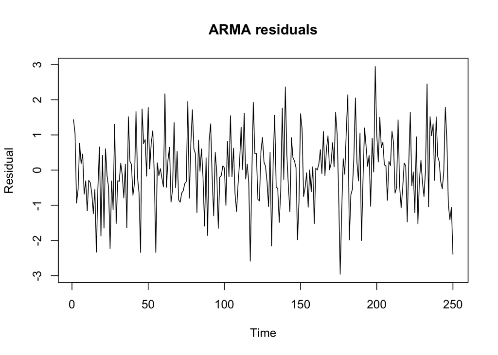

```r
res <- residuals(fit_arma)
plot.ts(res, main = "ARMA residuals", ylab = "Residual")
```

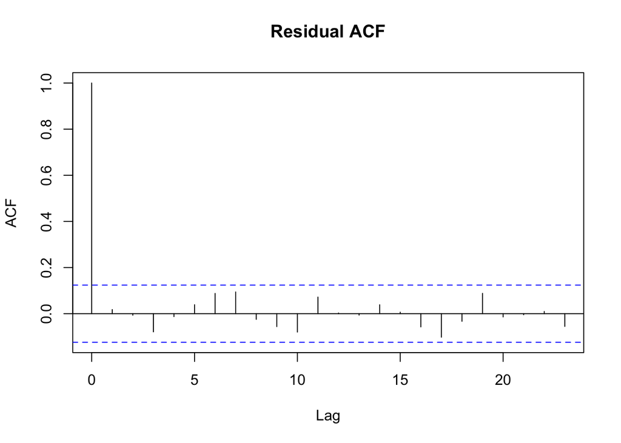

```r
acf(res, main = "Residual ACF")
```

```r
Box.test(res, lag = 12, type = "Ljung-Box", fitdf = 2)  # fitdf = p + q
```

```
##
##  Box-Ljung test
##
## data:  res
## X-squared = 10.42, df = 10, p-value = 0.4045
```

What the commands do:

- `residuals()` extracts the fitted model’s one-step prediction errors.
- `Box.test()` checks residual autocorrelations jointly through lag 12.
- `fitdf = 2` adjusts for the fitted AR and MA coefficients, giving $12 - 2 = 10$ test degrees of freedom. A large p-value means insufficient evidence of remaining autocorrelation; it does not prove white noise.

Try it yourself:

- Apply the same plots and test to `fit_ar`, using `fitdf = 1`.
- Does the simpler model leave a pattern that the ARMA model removes?

Questions:

- Do the residuals look like white noise?
- Why is `fitdf = 2`?

## 4. Parameter Redundancy

Fit an ARMA(1,1) to Gaussian iid white noise and compare the roots of the fitted AR polynomial $\hat\phi(z) = 1 - \hat\phi z$ and MA polynomial $\hat\theta(z) = 1 - \hat\theta z$.

```r
set.seed(5)
w <- ts(rnorm(200))
fit_w <- arima(w, order = c(1, 0, 1))
fit_w
```

```
##
## Call:
## arima(x = w, order = c(1, 0, 1))
##
## Coefficients:
##           ar1     ma1  intercept
##       -0.8348  0.7686     0.0242
## s.e.   0.1129  0.1256     0.0671
##
## sigma^2 estimated as 0.9701:  log likelihood = -280.77,  aic = 569.53
```

```r
theta_hat <- -coef(fit_w)["ma1"]          # R's ma1 is -theta_hat
c(AR_root = 1 / unname(coef(fit_w)["ar1"]),
  MA_root = 1 / unname(theta_hat))
```

```
##   AR_root   MA_root
## -1.197924 -1.301083
```

```r
fit_wn <- arima(w, order = c(0, 0, 0))    # white noise with a mean
AIC(fit_w, fit_wn)
```

```
##        df      AIC
## fit_w   4 569.5339
## fit_wn  2 568.3811
```

Questions:

- Are the two roots nearly equal? What model remains after cancelling them?
- Which model does AIC prefer?

### Exact Cancellation Before Estimation

If $\phi = \theta$, the model equation is

$$(1 - \phi B)X_t = (1 - \phi B)\epsilon_t.$$

For the stationary solution with $|\phi| < 1$, cancelling the common factor leaves white noise. Thus a fitted ARMA model can contain two unnecessary coefficients. Compare exact cancellation with nearby factors.

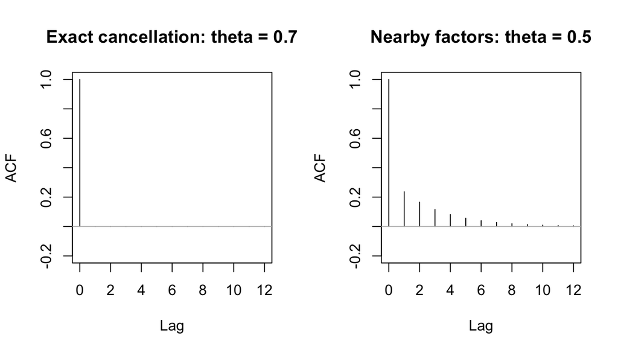

```r
par(mfrow = c(1, 2))
plot(0:12, ARMAacf(ar = 0.7, ma = -0.7, lag.max = 12),
     type = "h", ylim = c(-0.2, 1), xlab = "Lag", ylab = "ACF",
     main = "Exact cancellation: theta = 0.7")
abline(h = 0, col = "grey")
plot(0:12, ARMAacf(ar = 0.7, ma = -0.5, lag.max = 12),
     type = "h", ylim = c(-0.2, 1), xlab = "Lag", ylab = "ACF",
     main = "Nearby factors: theta = 0.5")
abline(h = 0, col = "grey")
```

```r
par(mfrow = c(1, 1))
```

Questions:

- Why are all non-zero-lag correlations zero in the first plot?
- Why can nearby factors make the coefficients hard to estimate separately?
- How does this explain the fitting experiment in Part 2?